# Exploratory Data Analysis: Exercise 2: CHIS

Springboard: Foundations of Data Science

Antoine Beauchamp

January 29th, 2017

## Introduction

In this exercise we will make use of the California Health Interview Survey data from 2009 to analyze the relationship between participants’ age and their BMI. The specific data set that we will be working with is the `chis09_adult_spss` data set, which can be obtained from http://healthpolicy.ucla.edu. Everything will be done locally.

Let’s begin by clearing the working environment, loading the required libraries, and setting the working environment.

```r
#Clear working environment.
rm(list=ls())

#Load libraries
suppressMessages(library(dplyr))
library(haven)
library(ggplot2)
library(ggthemes)

#Set the wd
path_to_wd <- file.path("~","Documents","Work","DataScience","Springboard","FoundationsofDataScience","Section4_ExploratoryDataAnalysis","Section4_Ex2")
setwd(path_to_wd)
rm(path_to_wd)
```

Now we will import the data into a data frame, and select the subset of variables used in the DataCamp exercise. These variables are as follows:

- `RBMI`: BMI Category Description
- `BMI_P`: BMI Value
- `RACEHPR2`: Race
- `SRSEX`: Sex
- `SRAGE_P`: Age
- `MARIT2`: Marital Status
- `AB1`: General Health Condition
- `ASTCUR`: Current Asthma Status
- `AB51`: Type 1 or 2 Diabeters
- `POVLL`: Poverty Level.

```r
adult_full <- as.data.frame(read_spss("./chis09_adult_spss/chis09_adult_spss/ADULT.sav"))
adult <- adult_full %>% select(RBMI,BMI_P,RACEHPR2,SRSEX,SRAGE_P,MARIT2,AB1,ASTCUR,AB51,POVLL)
```

## Exploring Data

With our data loaded, let’s examine our data and generate some basic exploratory histograms.

```r
# Explore the dataset with summary and str
summary(adult)
```

```
##       RBMI          BMI_P          RACEHPR2         SRSEX
##  Min.   :1.00   Min.   :12.65   Min.   :1.000   Min.   :1.000
##  1st Qu.:2.00   1st Qu.:22.82   1st Qu.:5.000   1st Qu.:1.000
##  Median :3.00   Median :25.74   Median :6.000   Median :2.000
##  Mean   :2.76   Mean   :26.73   Mean   :5.169   Mean   :1.592
##  3rd Qu.:3.00   3rd Qu.:29.43   3rd Qu.:6.000   3rd Qu.:2.000
##  Max.   :4.00   Max.   :93.72   Max.   :7.000   Max.   :2.000
##     SRAGE_P          MARIT2          AB1           ASTCUR
##  Min.   :18.00   Min.   :1.00   Min.   :1.00   Min.   :1.000
##  1st Qu.:44.00   1st Qu.:1.00   1st Qu.:2.00   1st Qu.:2.000
##  Median :57.00   Median :1.00   Median :2.00   Median :2.000
##  Mean   :55.67   Mean   :2.05   Mean   :2.54   Mean   :1.913
##  3rd Qu.:69.00   3rd Qu.:3.00   3rd Qu.:3.00   3rd Qu.:2.000
##  Max.   :85.00   Max.   :4.00   Max.   :5.00   Max.   :2.000
##       AB51             POVLL
##  Min.   :-1.0000   Min.   :1.000
##  1st Qu.:-1.0000   1st Qu.:2.000
##  Median :-1.0000   Median :4.000
##  Mean   :-0.7051   Mean   :3.163
##  3rd Qu.:-1.0000   3rd Qu.:4.000
##  Max.   : 3.0000   Max.   :4.000
```

```r
str(adult)
```

```
## 'data.frame':    47614 obs. of  10 variables:
##  $ RBMI    :Class 'labelled'  atomic [1:47614] 3 3 3 2 3 4 2 3 2 3 ...
##   .. ..- attr(*, "label")= chr "BMI DESCRIPTIVE"
##   .. ..- attr(*, "format.spss")= chr "F8.0"
##   .. ..- attr(*, "labels")= Named num [1:5] -9 1 2 3 4
##   .. .. ..- attr(*, "names")= chr [1:5] "NOT ASCERTAINED" "UNDERWEIGHT 0-18.49" "NORMAL 18.5-24.99" "OVERWEIGHT 25.0-29.99" ...
##  $ BMI_P   :Class 'labelled'  atomic [1:47614] 28.9 26.1 25.1 25 25.1 ...
##   .. ..- attr(*, "label")= chr "BODY MASS INDEX (PUF RECODE)"
##   .. ..- attr(*, "format.spss")= chr "F8.2"
##   .. ..- attr(*, "labels")= Named num -9
##   .. .. ..- attr(*, "names")= chr "NOT ASCERTAINED"
##  $ RACEHPR2:Class 'labelled'  atomic [1:47614] 6 6 6 6 6 6 2 6 6 6 ...
##   .. ..- attr(*, "label")= chr "RACE - UCLA CHPR DEFINITION, UNBRIDGED"
##   .. ..- attr(*, "format.spss")= chr "F3.0"
##   .. ..- attr(*, "labels")= Named num [1:7] 1 2 3 4 5 6 7
##   .. .. ..- attr(*, "names")= chr [1:7] "LATINO" "PACIFIC ISLANDER" "AMERICAN INDIAN/ALASKAN NATIVE" "ASIAN" ...
##  $ SRSEX   :Class 'labelled'  atomic [1:47614] 1 2 1 1 1 2 2 1 2 1 ...
##   .. ..- attr(*, "label")= chr "GENDER"
##   .. ..- attr(*, "format.spss")= chr "F3.0"
##   .. ..- attr(*, "labels")= Named num [1:2] 1 2
##   .. .. ..- attr(*, "names")= chr [1:2] "MALE" "FEMALE"
##  $ SRAGE_P : atomic  32 80 71 39 75 53 67 42 33 67 ...
##   ..- attr(*, "label")= chr "AGE (PUF RECODE)"
##   ..- attr(*, "format.spss")= chr "F8.0"
##  $ MARIT2  :Class 'labelled'  atomic [1:47614] 1 3 1 4 1 1 1 1 1 3 ...
##   .. ..- attr(*, "label")= chr "MARITAL STATUS- 4 CATEGORIES"
##   .. ..- attr(*, "format.spss")= chr "F8.0"
##   .. ..- attr(*, "labels")= Named num [1:5] -9 1 2 3 4
##   .. .. ..- attr(*, "names")= chr [1:5] "NOT ASCERTAINED" "MARRIED" "LIVING W/ PARTNER" "WID/SEP/DIV" ...
##  $ AB1     :Class 'labelled'  atomic [1:47614] 1 1 2 1 2 3 2 2 2 1 ...
##   .. ..- attr(*, "label")= chr "GENERAL HEALTH CONDITION"
##   .. ..- attr(*, "format.spss")= chr "F3.0"
##   .. ..- attr(*, "labels")= Named num [1:9] -9 -8 -7 -1 1 2 3 4 5
##   .. .. ..- attr(*, "names")= chr [1:9] "NOT ASCERTAINED" "DON'T KNOW" "REFUSED" "INAPPLICABLE" ...
##  $ ASTCUR  :Class 'labelled'  atomic [1:47614] 2 2 1 2 2 1 2 2 2 2 ...
##   .. ..- attr(*, "label")= chr "CURRENT ASTHMA STATUS"
##   .. ..- attr(*, "format.spss")= chr "F8.0"
##   .. ..- attr(*, "labels")= Named num [1:3] -9 1 2
##   .. .. ..- attr(*, "names")= chr [1:3] "NOT ASCERTAINED" "CURRENT ASTHMA" "NO CURRENT ASTHMA"
##  $ AB51    :Class 'labelled'  atomic [1:47614] -1 -1 -1 -1 -1 -1 -1 -1 -1 -1 ...
##   .. ..- attr(*, "label")= chr "TYPE I OR TYPE II DIABETES"
##   .. ..- attr(*, "format.spss")= chr "F3.0"
##   .. ..- attr(*, "labels")= Named num [1:7] -9 -8 -7 -1 1 2 3
##   .. .. ..- attr(*, "names")= chr [1:7] "NOT ASCERTAINED" "DON'T KNOW" "REFUSED" "INAPPLICABLE" ...
##  $ POVLL   :Class 'labelled'  atomic [1:47614] 4 4 4 4 4 4 4 4 3 4 ...
##   .. ..- attr(*, "label")= chr "POVERTY LEVEL"
##   .. ..- attr(*, "format.spss")= chr "F8.0"
##   .. ..- attr(*, "labels")= Named num [1:4] 1 2 3 4
##   .. .. ..- attr(*, "names")= chr [1:4] "0-99% FPL" "100-199% FPL" "200-299% FPL" "300% FPL AND ABOVE"
```

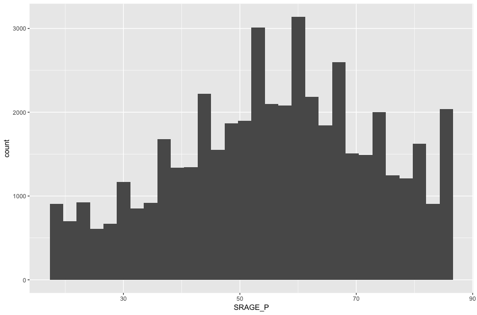

**Figure 1**: Basic Age Histogram

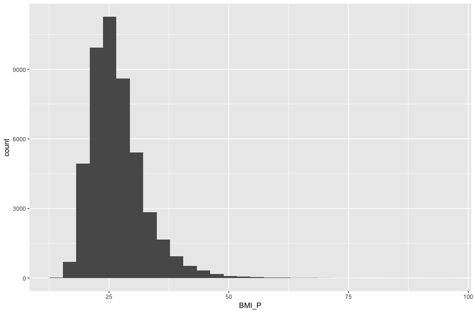

**Figure 2**: Basic BMI Histogram

```r
# Age histogram
ggplot(adult, aes(x=SRAGE_P))+geom_histogram()

# BMI histogram
ggplot(adult, aes(x=BMI_P))+geom_histogram()
```

We can note that our binwidth value isn’t particularly suited to this data, since we are only using 30 bins. Let’s refine the age histogram by setting a `binwidth=1` and including the BMI information on the colour scale:

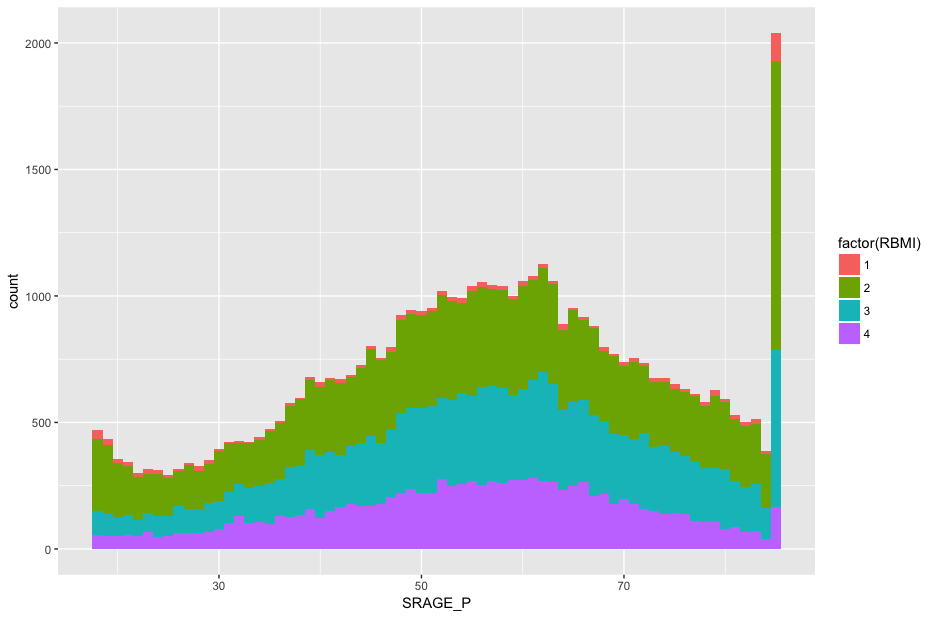

**Figure 3**: Age Histogram Coloured by BMI

```r
# Age colored by BMI, default binwidth
ggplot(adult, aes(x=SRAGE_P, col=BMI_P, fill=factor(RBMI)))+geom_histogram(binwidth=1)
```

## Data Cleaning

Figure 3 looks much better and gives us some idea of the data, but we can notice that there are some improvements that can be made. As noted on DataCamp, it appears that all the participants aged 85 and above were binned into the same category. We will correct this by removing these values from the data.

We will also narrow down the number of races included in the data set and label them as well.

Finally, our legend for the colour scheme in Figure 3 is not exactly instructive, so we will convert the BMI categorical data to factors and add appropriate labels.

```r
# Remove individual aboves 84
adult <- adult[adult$SRAGE_P <= 84, ]

# Remove individuals with a BMI below 16 and above or equal to 52
adult <- adult[adult$BMI_P >= 16 & adult$BMI_P < 52, ]

# Filter rows so that we only have the following races: Latino, Asian, African American, White
adult <- adult %>% filter(RACEHPR2 %in% c(1,4,5,6))

# Relabel the race variable:
adult$RACEHPR2 <- factor(adult$RACEHPR2, labels = c("Latino", "Asian", "African American", "White"))

# Relabel the BMI categories variable:
adult$RBMI <- factor(adult$RBMI, labels = c("Under-weight","Normal-weight", "Over-weight", "Obese"))
```

## Multiple Histograms

In this section, we continue to examine our now clean data using multiple histograms, which we will implement with a facet grid.

```r
# The color scale used in the plot
BMI_fill <- scale_fill_brewer("BMI Category", palette = "Reds")

# Theme to fix category display in faceted plot
fix_strips <- theme(strip.text.y = element_text(angle = 0, hjust = 0, vjust = 0.1, size = 14), strip.background = element_blank(), legend.position = "none")
```

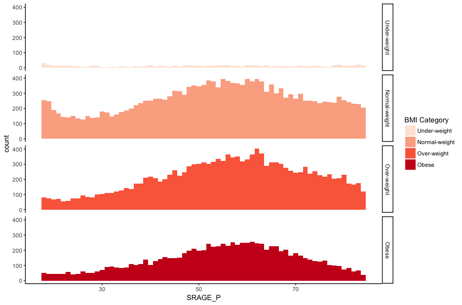

**Figure 4**: Age Histogram Faceted According to BMI

```r
# Histogram, add BMI_fill and customizations
#ggplot(adult, aes (x = SRAGE_P, fill= factor(RBMI))) + geom_histogram(binwidth = 1) + fix_strips + BMI_fill + facet_grid(RBMI~.)+theme_classic()
ggplot(adult, aes(x=SRAGE_P, fill=factor(RBMI)))+geom_histogram(binwidth=1) + facet_grid(RBMI~.)+theme_classic()+BMI_fill+fix_strips
```

## Alternatives

So far we have been working solely with frequency histograms. In this section we examine the use of density histograms.

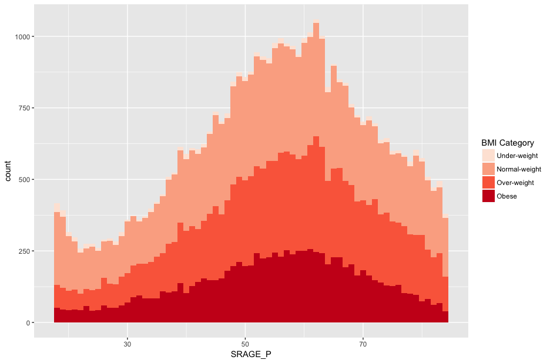

**Figure 5**: Age Frequency Histogram Coloured by BMI

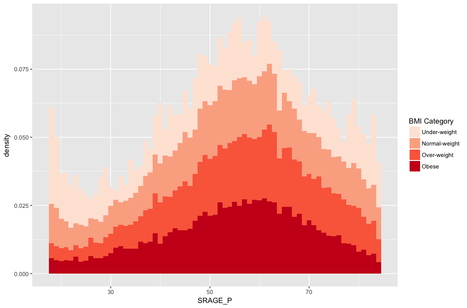

**Figure 6**: Age Density Histogram Coloured by BMI

```r
# Basic count histogram
ggplot(adult, aes (x = SRAGE_P, fill= factor(RBMI))) +
  geom_histogram(binwidth = 1) +
  BMI_fill

# Density histogram
ggplot(adult, aes (x = SRAGE_P, fill= factor(RBMI))) +
  geom_histogram(binwidth = 1, aes(y=..density..)) +
  BMI_fill
```

Figure 6 is strange since the “Under-weight” category values appear larger than we would expect them to be. As mentioned on DataCamp, this is because when using the `..density..` variable from the `ggplot` internal data frame, R is in fact calculating the density **within each sub-group**, and not the density as part of the full data.

We can also examine the faceted plots for both frequency and density histograms:

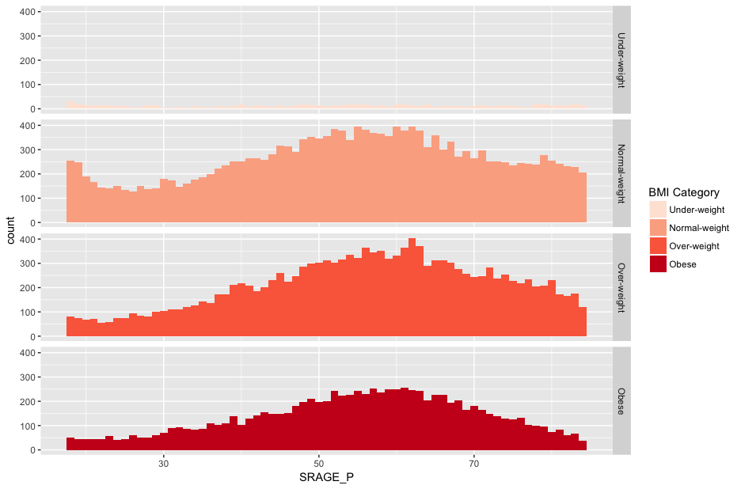

**Figure 7**: Age Frequency Histogram Faceted According to BMI

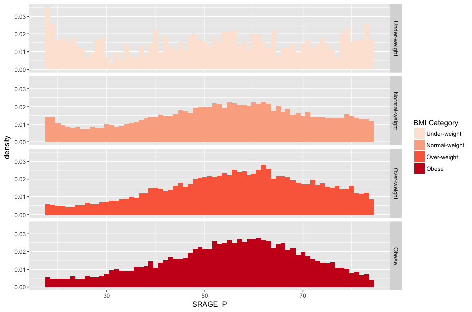

**Figure 8**: Age Density Histogram Faceted According to BMI

```r
# Faceted count histogram
ggplot(adult, aes (x = SRAGE_P, fill= factor(RBMI))) +
  geom_histogram(binwidth = 1) +
  BMI_fill +facet_grid(RBMI~.)


# Faceted density histogram
ggplot(adult, aes (x = SRAGE_P, fill= factor(RBMI))) +
  geom_histogram(binwidth = 1, aes(y=..density..)) +
  BMI_fill + facet_grid(RBMI~.)
```

Again we see the same issue of over-representation in Figure 8 due to the computation of density based on each category. We will generate a “filled” histogram to reinforce this point:

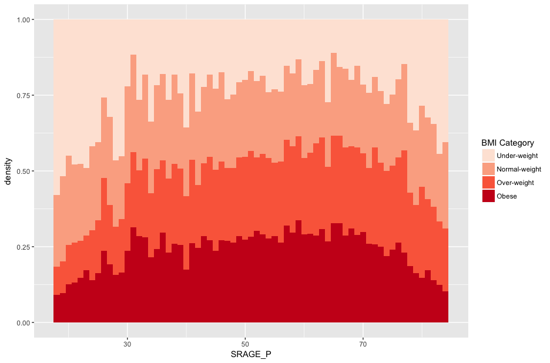

**Figure 9**: Filled Age Density Histogram Coloured by BMI, Incorrect

```r
# Density histogram with position = "fill"
ggplot(adult, aes (x = SRAGE_P, fill= factor(RBMI))) +
  geom_histogram(binwidth = 1, aes(y=..density..), position="fill") +
  BMI_fill
```

The proportions are off. In order to generate the density histogram that we want, i.e. with the densities representing the proportion across the entire data set, we need to compute our own density values using the `ggplot` internal data frame variable `..count..`.

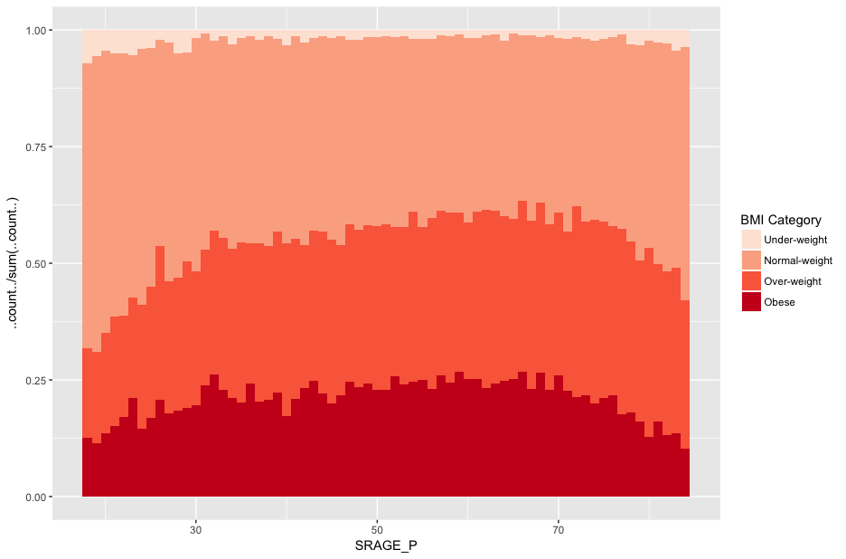

**Figure 10**: Filled Age Density Histogram Coloured by BMI, Correct

```r
# The accurate histogram
ggplot(adult, aes (x = SRAGE_P, fill= factor(RBMI))) +
  geom_histogram(binwidth = 1, aes(y=..count../sum(..count..)), position="fill") +
  BMI_fill
```

That looks much better.

In the next section we will attempt to facet this plot as we did with the frequency and incorrect density histograms above.

## Do Things Manually

Let’s begin by attempting to create a faceted plot in the standard way:

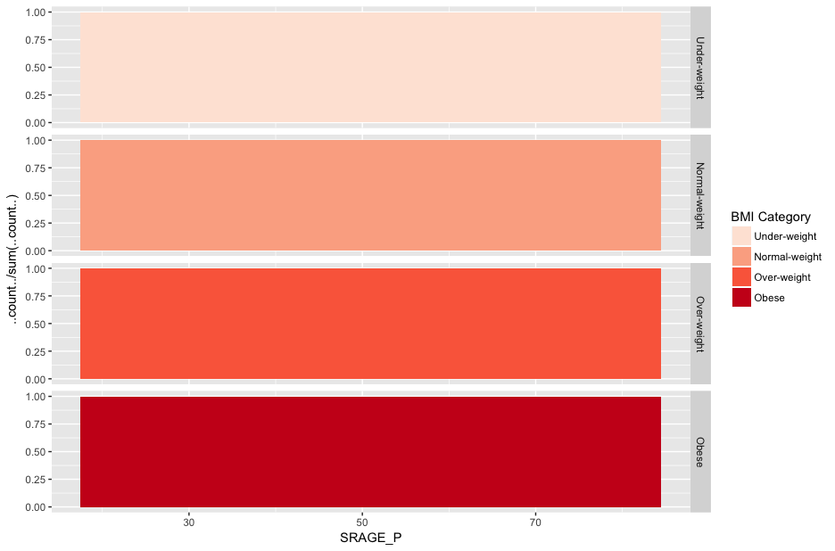

**Figure 11**: Naive Age Density Histogram Faceted by BMI, Incorrect

```r
# An attempt to facet the accurate frequency histogram from before (failed)
ggplot(adult, aes (x = SRAGE_P, fill= factor(RBMI))) +
  geom_histogram(aes(y = ..count../sum(..count..)), binwidth = 1, position = "fill") +
  BMI_fill +
  facet_grid(RBMI ~ .)
```

This is clearly not what we want. We seem to have lost all the information about the distribution. According to DataCamp, this error occurs because computing `..count../sum(..count..)` occurs on the fly inside of `ggplot`. We have to calculate the density proportions manually outside of `ggplot`.

We can begin to do this by building a contingency table using `RBMI` and `SRAGE_P`. This will create a table with the count for each combination of factor levels within the variables. In this case, each age group will be treated as a factor level. Therefore, for each age value, we will have the count of occurrences within each BMI category.

```r
# Create our contingency table
DF <- table(adult$RBMI, adult$SRAGE_P)

DF[,1:10]
```

```
##
##                  18  19  20  21  22  23  24  25  26  27
##   Under-weight   30  22  14  15  13  15  11  10   6   8
##   Normal-weight 254 248 191 168 145 142 151 133 128 150
##   Over-weight    80  76  68  70  56  59  73  73  95  83
##   Obese          52  45  43  45  44  58  40  44  60  52
```

In this table, each column represents an age group, while each row represents a BMI category.

```r
# Use apply on DF to get frequency of each group
# The argument '2' indicates the apply function should be mapped across the columns,
# rather than the rows.
DF_freq<-apply(DF, 2, function(x) {x/sum(x)})

DF_freq[,1:10]
```

```
##
##                         18         19        20         21        22
##   Under-weight  0.07211538 0.05626598 0.0443038 0.05033557 0.0503876
##   Normal-weight 0.61057692 0.63427110 0.6044304 0.56375839 0.5620155
##   Over-weight   0.19230769 0.19437340 0.2151899 0.23489933 0.2170543
##   Obese         0.12500000 0.11508951 0.1360759 0.15100671 0.1705426
##
##                         23        24         25         26         27
##   Under-weight  0.05474453 0.0400000 0.03846154 0.02076125 0.02730375
##   Normal-weight 0.51824818 0.5490909 0.51153846 0.44290657 0.51194539
##   Over-weight   0.21532847 0.2654545 0.28076923 0.32871972 0.28327645
##   Obese         0.21167883 0.1454545 0.16923077 0.20761246 0.17747440
```

We now have a table of densities within each subgroup.

Let’s convert this table back into a data frame using the `melt()` function. We will also create names for our variables.

```r
# Load reshape2 and use melt on DF to create DF_melted
library(reshape2)
DF_melted <- melt(DF_freq)

# Change names of DF_melted
names(DF_melted) <- c("FILL", "X", "value")

head(DF_melted)
```

```
##            FILL  X      value
## 1  Under-weight 18 0.07211538
## 2 Normal-weight 18 0.61057692
## 3   Over-weight 18 0.19230769
## 4         Obese 18 0.12500000
## 5  Under-weight 19 0.05626598
## 6 Normal-weight 19 0.63427110
```

Now that we have our proper density values, let’s make the faceted plot that we intended to make. Note that we have to do this a little differently since we have computed the density values explicitly. We can’t just use the `geom_histogram` geometry.

```r
# Add code to make this a faceted plot
ggplot(DF_melted, aes(x = X, y = value, fill = FILL)) +
  geom_bar(stat = "identity", position = "stack") +
  BMI_fill + facet_grid(FILL ~ .)
```

This is the faceted plot that we were looking for.

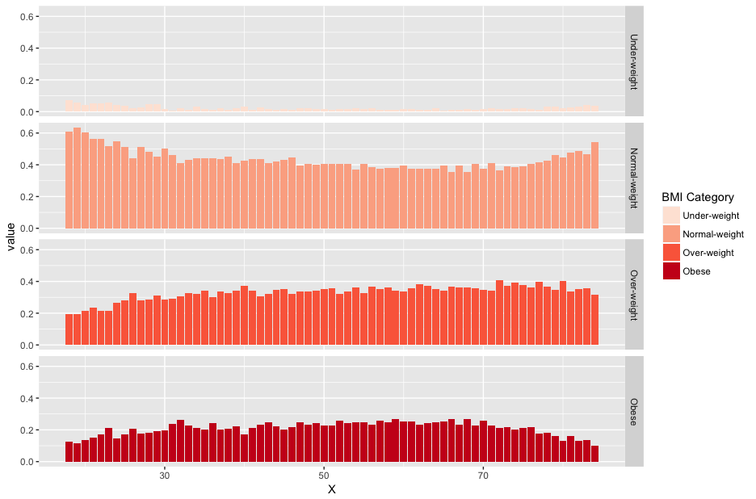

**Figure 12**: Age Density Histogram Faceted by BMI, Correct

## Merimeko/Mosaic Plot

In this section we will create a mosaic plot. The purpose of this plot is to encode the density values as we did previously with the filled histogram. However we additionally want to encode the information about the number of absolute counts within each age group. In order to do this, we will generate a sort of stacked bar plot where the height of the bars represents the density and the width of the bars represents the absolute count. Each bar will represent one age group.

Let’s start by creating the same contingency table as above, and converting it to a data frame. What we end up with is a data frame in which the age values form the names of the rows and the BMI categories form the names of the columns. The data frame is populated by the corresponding counts.

```r
# The initial contingency table
DF <- as.data.frame.matrix(table(adult$SRAGE_P, adult$RBMI))

head(DF)
```

```
##    Under-weight Normal-weight Over-weight Obese
## 18           30           254          80    52
## 19           22           248          76    45
## 20           14           191          68    43
## 21           15           168          70    45
## 22           13           145          56    44
## 23           15           142          59    58
```

Next we want to compute some information about how many **total** counts, i.e. across all BMI categories, are included in each age group. We will encode this into the width of the bars by computing the corresponding `xmin` and `xmax` values.

```r
# First compute the total counts within each age group. Since age is stored in rows within the data frame, this is a simple sum across the columns.
DF$groupSum <- rowSums(DF)

# The value that we will use as xmax is the count sum for a given age group, added to the count sum for the previous age group. The xmin value for a given age group begins where the xmax from the previous group ends.
DF$xmax <- cumsum(DF$groupSum)
DF$xmin <- DF$xmax - DF$groupSum

# The groupSum column needs to be removed, don't remove this line
DF$groupSum <- NULL
```

Since the age values are currently being stored as row names, let’s convert them to variables in the data frame.

```r
# Copy row names to variable X
DF$X <- row.names(DF)

head(DF)
```

```
##    Under-weight Normal-weight Over-weight Obese xmax xmin  X
## 18           30           254          80    52  416    0 18
## 19           22           248          76    45  807  416 19
## 20           14           191          68    43 1123  807 20
## 21           15           168          70    45 1421 1123 21
## 22           13           145          56    44 1679 1421 22
## 23           15           142          59    58 1953 1679 23
```

The current data frame is organized so that there is a variable for each of the BMI categories. We want to clean the data so that the BMI categories are stored in a variable, and their values are stored in a separate variable.

```r
# Melt the dataset
library(reshape2)
DF_melted <- melt(DF, id.vars = c("X","xmin", "xmax"), variable.name = "FILL")

head(DF_melted)
```

```
##    X xmin xmax         FILL value
## 1 18    0  416 Under-weight    30
## 2 19  416  807 Under-weight    22
## 3 20  807 1123 Under-weight    14
## 4 21 1123 1421 Under-weight    15
## 5 22 1421 1679 Under-weight    13
## 6 23 1679 1953 Under-weight    15
```

As mentioned above, for our mosaic plot, we want to encode the densities of each sub-group into the height of the bar on our plot. We can do this in a way similar to the widths of the bars, by calculating `ymin` and `ymax`.

```r
# dplyr call to calculate ymin and ymax
DF_melted <- DF_melted %>%
  group_by(X) %>%
  mutate(ymax = cumsum(value/sum(value)),
         ymin = ymax - value/sum(value))
```

We are finally ready to generate our mosaic plot:

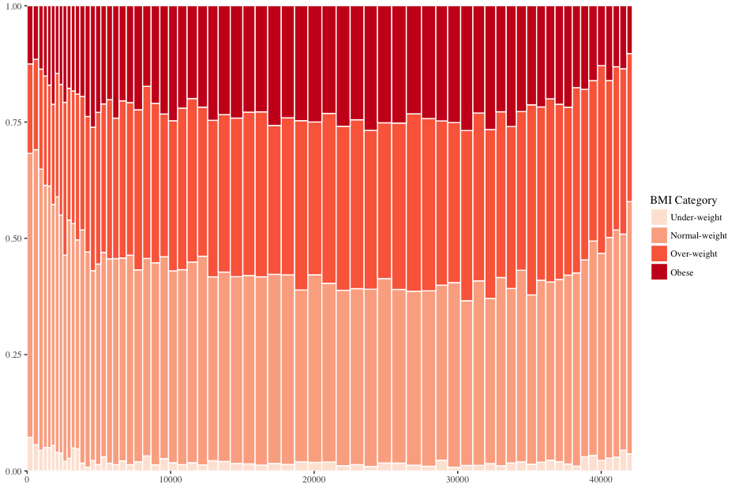

**Figure 13**: Mosaic/Merimeko Plot

```r
# Plot rectangles - don't change.
ggplot(DF_melted, aes(ymin = ymin,
                      ymax = ymax,
                      xmin = xmin,
                      xmax = xmax,
                      fill = FILL)) +
  geom_rect(colour = "white") +
  scale_x_continuous(expand = c(0,0)) +
  scale_y_continuous(expand = c(0,0)) +
  BMI_fill + theme_tufte()
```

Note that each individual bar represents one age group. The width of each bar is representative of the number of absolute counts within the given group. The height of each bar represents the density of the BMI values within the group.

## Adding Statistics

We will refine our mosaic plot by adding statistics to it, particularly the residuals of a chi-squared test.

```r
# Perform chi.sq test (RBMI and SRAGE_P)
results <- chisq.test(table(adult$RBMI, adult$SRAGE_P))

# Melt results$residuals and store as resid
resid=melt(results$residuals)

# Change names of resid
names(resid) <- c("FILL", "X", "residual")

# Merge the two datasets:
DF_all <- merge(DF_melted,resid)
```

Let’s now redo the mosaic plot, but mapping the residuals onto the fill scale, rather than the BMI categories.

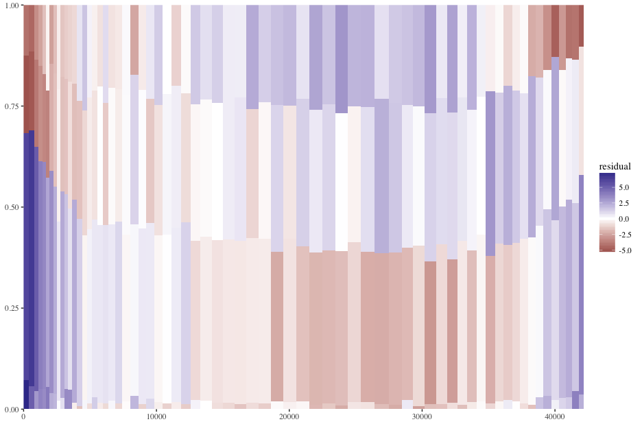

**Figure 14**: Residuals Mosaic Plot

```r
# Update plot command
ggplot(DF_all, aes(ymin = ymin,
                   ymax = ymax,
                   xmin = xmin,
                   xmax = xmax,
                   fill = residual)) +
  geom_rect() +
  scale_fill_gradient2() +
  scale_x_continuous(expand = c(0,0)) +
  scale_y_continuous(expand = c(0,0)) +
  theme_tufte()
```

## Adding Text

The plot above looks good but we can make it even better by adding some text.

We will add text on the x axis to identify the age group of each bar. First we set the positions where we want this text to appear. This will be in the center of each bar:

```r
# Position for labels on x axis
DF_all$xtext <- DF_all$xmin + (DF_all$xmax - DF_all$xmin)/2
```

We also want to add text on the y axis that indicates the difference between BMI categories.

```r
# Position for labels on y axis (don't change)
index <- DF_all$xmax == max(DF_all$xmax)
DF_all$ytext <- DF_all$ymin[index] + (DF_all$ymax[index] - DF_all$ymin[index])/2
```

We can now plot these improvements, while also changing the legend position.

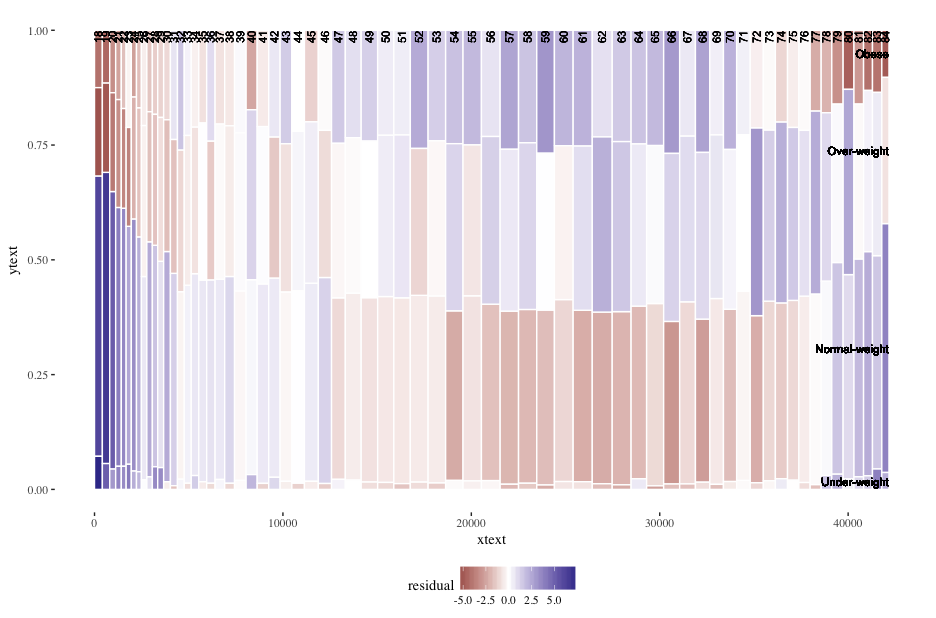

**Figure 15**: Residuals Mosaic Plot with Labels

```r
# Plot
ggplot(DF_all, aes(ymin = ymin, ymax = ymax, xmin = xmin,
                   xmax = xmax, fill = residual)) +
  geom_rect(col = "white") +
  # geom_text for ages (i.e. the x axis)
  geom_text(aes(x = xtext,
                label = X),
            y = 1,
            size = 3,
            angle = 90,
            hjust = 1,
            show.legend = FALSE) +
  # geom_text for BMI (i.e. the fill axis)
  geom_text(aes(x = max(xmax),
                y = ytext,
                label = FILL),
            size = 3,
            hjust = 1,
            show.legend  = FALSE) +
  scale_fill_gradient2() +
  theme_tufte() +
  theme(legend.position = "bottom")
```

This completes our mosaic plot outlining the relationship between age and BMI.

## Generalizations

In this final section, we will define a function that allows us to generate a mosaic plot for any data set.

Begin by loading all the required packages:

```r
# Load all packages
library(ggplot2)
library(reshape2)
library(dplyr)
library(ggthemes)
```

Write the script into a function, `mosaicGG`:

```r
# Script generalized into a function
mosaicGG <- function(data, X, FILL) {

  # Proportions in raw data
  # This section takes the data that we want to plot and calculates the
  # appropriate rectangle widths and rectangle heights, as we did above.
  DF <- as.data.frame.matrix(table(data[[X]], data[[FILL]]))
  DF$groupSum <- rowSums(DF)
  DF$xmax <- cumsum(DF$groupSum)
  DF$xmin <- DF$xmax - DF$groupSum
  DF$X <- row.names(DF)
  DF$groupSum <- NULL
  DF_melted <- melt(DF, id = c("X", "xmin", "xmax"), variable.name = "FILL")
  library(dplyr)
  DF_melted <- DF_melted %>%
    group_by(X) %>%
    mutate(ymax = cumsum(value/sum(value)),
           ymin = ymax - value/sum(value))

  # Chi-sq test
  # In this section we perform a chi-squared test on the variables and
  # extract the residuals.
  results <- chisq.test(table(data[[FILL]], data[[X]])) # fill and then x
  resid <- melt(results$residuals)
  names(resid) <- c("FILL", "X", "residual")

  # Merge data
  DF_all <- merge(DF_melted, resid)

  # Positions for labels
  # Here we set the positions for the x axis labels and the y axis labels
  DF_all$xtext <- DF_all$xmin + (DF_all$xmax - DF_all$xmin)/2
  index <- DF_all$xmax == max(DF_all$xmax)
  DF_all$ytext <- DF_all$ymin[index] + (DF_all$ymax[index] - DF_all$ymin[index])/2

  # Plot:
  g <- ggplot(DF_all, aes(ymin = ymin,  ymax = ymax, xmin = xmin,
                          xmax = xmax, fill = residual)) +
    geom_rect(col = "white") +
    geom_text(aes(x = xtext, label = X),
              y = 1, size = 3, angle = 90, hjust = 1, show.legend = FALSE) +
    geom_text(aes(x = max(xmax),  y = ytext, label = FILL),
              size = 3, hjust = 1, show.legend = FALSE) +
    scale_fill_gradient2("Residuals") +
    scale_x_continuous("Individuals", expand = c(0,0)) +
    scale_y_continuous("Proportion", expand = c(0,0)) +
    theme_tufte() +
    theme(legend.position = "bottom")
  print(g)
}
```

To finish off, we will apply our mosaic plotting function to a number of different variables and data sets.

From the CHIS data set:

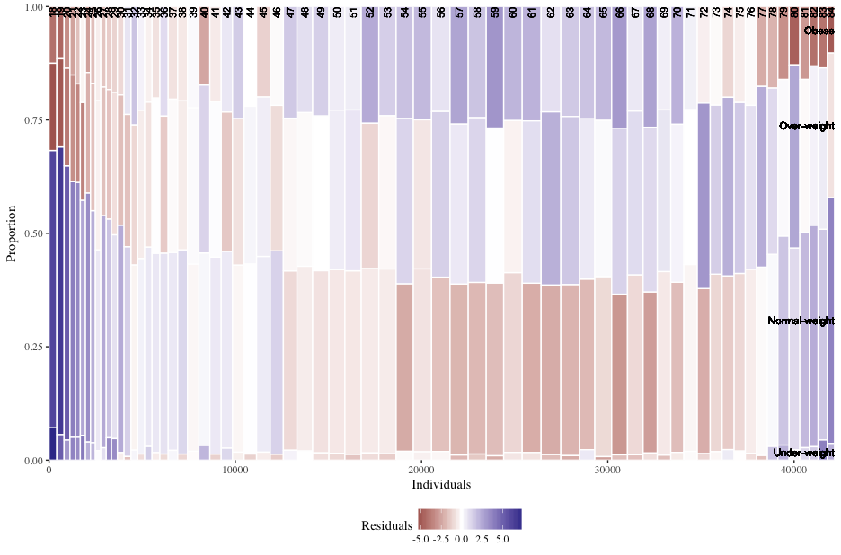

**Figure 16**: Mosaic Plot Describing Age and BMI Residuals

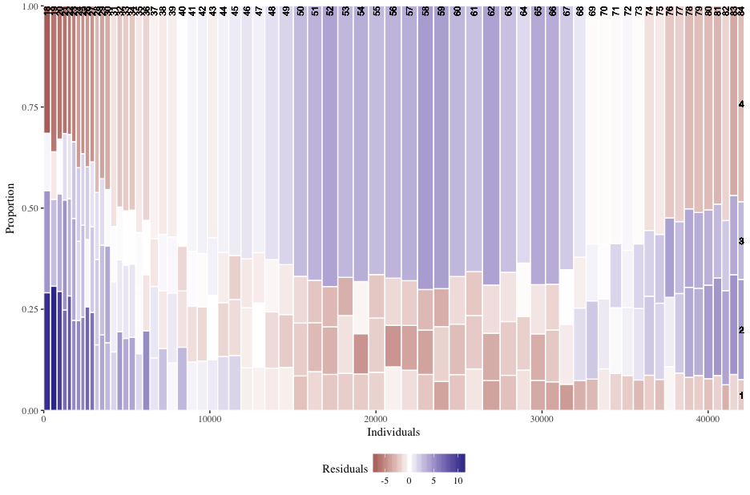

**Figure 17**: Mosaic Plot Describing Age and Poverty Level Residuals

```r
# BMI described by age
mosaicGG(adult, "SRAGE_P", "RBMI")

# Poverty described by age
mosaicGG(adult, "SRAGE_P", "POVLL")
```

From the `mtcars` data set:

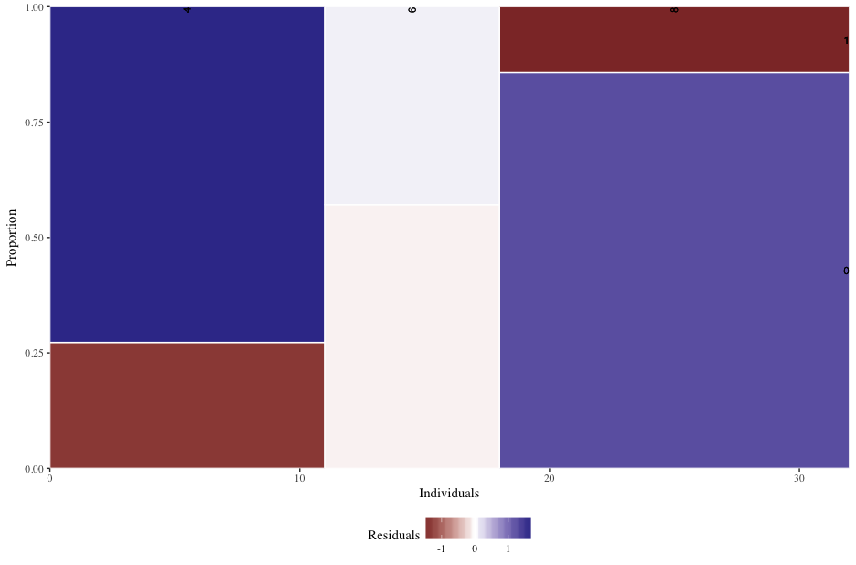

**Figure 18**: Mosaic Plot Describing `cyl` and `am` Residuals

```r
# mtcars: am described by cyl
mosaicGG(mtcars, "cyl", "am")
```

From the `Vocab` data set:

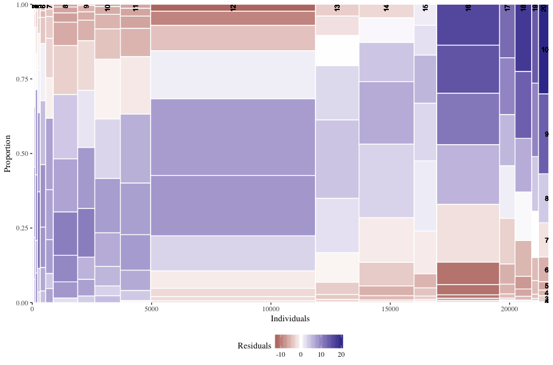

**Figure 19**: Mosaic Plot Describing Education and Vocabulary Residuals

```r
# Vocab: vocabulary described by education
library(car)
mosaicGG(Vocab, "education", "vocabulary")
```

This concludes our analysis. Until next time.